### 2nd European Conference on Social Networks, June 14-17, 2016, Paris (http://eusn2016.sciencesconf.org/)

### Contributed paper at Session 23: *Modelling networks* (June 15, 9h25 - 13h05)

# SOCIAL INFLUENCE NETWORKS

## By Moses Boudourides and Sergios Lenis

## University of Patras, Greece

## Graphs Assumptions & Notation

- Let $G = (V, E)$ be a **simple undirected graph** with n vertices, i.e., $n = |V|$, so that, without any loss of generality,

\begin{equation} V = [n], \end{equation}\begin{equation} E = \{(i,j)\!: i \sim j, i, j \in V, i \neq j\}. \end{equation}

- For any finite set $X$, $|X|$ denotes the number of elements of $X$.
- For any positive integer $k$, $[k]$ denotes the set of integers from 1 to $k,$ i.e., $[k] = \{1, 2, \ldots, k\}$.
- If vertices $i$ and $j$ are adjacent, we write $i \sim j$.
- $\deg(i)$ denotes the **degree** of $i$.
- $G$ is assumed to be **connected** (i.e., for any $i, \deg(i) \neq 0$).
- $A = \{A_{ij}\}_{i, j \in [n]}$ denotes the **adjacency matrix** of $G$.
- $N = \{N_{ij}\}_{i, j \in [n]}$ denotes the **walk matrix** (or the **adjacent averaging operator**) of $G$, which is defined as

\begin{equation} N = D^{-1} \, A, \end{equation}

where $D$ is the **diagonal degree matrix** with entries equal to the degree $\deg(i)$ of vertex $i$. Notice that

\begin{equation} N_{ij} = \left\{ \begin{array}{lr} \frac{1}{\deg(i)}, & {\mbox{ whenever }} i \sim j, \\ 0, & {\mbox{ otherwise, }} \end{array} \right. \end{equation}

- Finally, $L = \{L_{ij}\}_{i, j \in [n]}$ denotes the **(combinatorial) Laplacian matrix** of $G$, which is defined as

\begin{eqnarray} L &=& D - A \\ \nonumber &=& D(I - N), \end{eqnarray}

where $I$ is the **unit matrix**, i.e., as \begin{equation} L_{ij} = \left{ \begin{array}{lr} \deg(i), & {\mbox{ whenever }} i = j, \ -1, & {\mbox{ whenever }} i \sim j, \ 0, & {\mbox{ otherwise. }} \end{array} \right. \end{equation}

## The DeGroot-Friedkin-Johnsen Model of Social Influence

- $G$ is a **graph of persons**, i.e., *vertices $\equiv$ persons*.
- For each person $i \in V$ and time $t = 0, 1, 2, \ldots$ (in the discrete case considered here), $v^t(i) \in \mathbb{R}$ denotes $i$'s **opinion** at time $t$.
- Person's $i$ opinion at time $t$ is updated at next instance $t + 1$ as follows:

\begin{equation} v^{t + 1}(i) = s_i \, N \, v^t(i) + (1 - s_i) \, v^0(i), \end{equation}

- where $N \, v^t(i)$ is the average opinion of $i$'s neighbors
- and $s_{i}$ is person's $i$ **susceptibility coefficient**, a scalar parameter in the interval $[0, 1]$. Moreover, $s = \{s_i\}_{i \in [n]} \in [0,1]^{n}$ denotes the vector of susceptibility coefficients of all persons (vertices) in $G$ and $S$ is the $n \times n$ diagonal matrix with its diagonal entries equal to the $s_i$'s.
- If $s_i = 0$, then $i$'s opinion does not change ($v^{t + 1}(i) = v^0(i)$). Such a person is called **stubborn** or **persistent** in her opinion.
- If $s_i = 1$, then $i$ adopts the average opinion of her neighbors $N \, v^t(i)$. Such a person is called **malleable** or **fully compliant** in adopting her neighbor's influence.
- If $0 < s_i < 1$, then $i$'s opinion is inserted in-between $N \, v^t(i)$ and $v^0(i)$, where the exact inserted position is weighted by $s_i$.

## A PDEs-Based Formulation

### Persons with zero susceptibilities form the "boundary" of persons with positive susceptibilities.

- Decomposition of the set $V$ of persons-vertices:

\begin{equation} V = \Omega \cup \delta \Omega, \end{equation}\begin{equation} \Omega = \{i \in V\!: s_i > 0\}, \end{equation}\begin{equation} \delta \Omega = \{i \in V\!: s_i = 0\}, \end{equation}

- Assumptions: \begin{equation} \delta = |\delta \Omega| < n, \end{equation} \begin{equation} \forall j \in \delta \Omega, \exists i \in \Omega, i \sim j. \end{equation}

### The (Evolutionary) Initial Boundary Value Problem (IBVP)

\begin{eqnarray} v^{t + 1} &=& S \, N \, v^t + (I - S) \, \phi, {\mbox{ in }} \Omega, t > 0 \\ v^t &=& 1, {\mbox{ on }} \delta \Omega, t > 0 \\ v^0 &=& \left\{ \begin{array}{lr} \phi, & {\mbox{ in }} \Omega, \\ 1, & {\mbox{ on }} \delta \Omega. \end{array} \right. \end{eqnarray}

To solve this problem one needs to first consider the problem for the **rate of opinion change at the unit time step**, i.e.,

\begin{equation} u^t = v^t - v^{t - 1}, \end{equation}

which can be easily transformed to the following *linear parabolic IBVP with Dirichlet boundary conditions*:

\begin{eqnarray} w^{t + 1} &=& S \, (I - \mathcal{L}) \, w^t, {\mbox{ in }} \Omega, t > 0, \\ w^t &=& 0, {\mbox{ on }} \delta \Omega, t > 0, \\ w^1 &=& \left\{ \begin{array}{lr} D^{1/2} \, S \, (N - I) \, \phi, & {\mbox{ in }} \Omega, \\ 0, & {\mbox{ on }} \delta \Omega, \end{array} \right. \end{eqnarray}

where $\mathcal{L}$ is the **symmetric normalized Laplacian operator**.

Thus, spectral graph theory implies the existence of a unique solution $v^t = v^t(s,\phi)$, which may be expressed in terms of the $s$-dependent **Dirichlet heat kernel**:

\begin{equation} \mathcal{H}_t^s = (S \, (I - \mathcal{L}))^{t - 1}, t > 1. \end{equation}

Apparently, $S = I$ reduces the IBVP of social influence to the **difusion/heat equation**.

### The (Stationary) Boundary Value Problem (BVP)

After some standard transformations, the corresponsing stationary problem is easily seen to be (of the form):

\begin{eqnarray} \big(I - S \, (I - \mathcal{L} \big) \, \overline{w} &=& S \, D^{-1/2} \, (N - I) \, \phi, {\mbox{ in }} \Omega, \\ \overline{w} &=& 0, {\mbox{ on }} \delta \Omega, \end{eqnarray}

which is an *elliptic BVP with Dirichlet boundary conditions*.

Again, spectral graph theory guarantees the existence of a unique **steady state** solution $\overline{v} = \overline{v}(s,\phi)$, which can be expressed in terms of the $s$--dependent **Green function**:

\begin{equation} \mathcal{G}^s = \big(I - S \, (I - \mathcal{L})\big)^{-1}, \end{equation}

Again, when $S = I$, the BVP of social influence is reduced to the **Laplace/Poison equation**.

## The Case of a Continuous Steering by a Single Source of Influence

- $|\partial \Omega| = 1$ or $\partial \Omega = \{i[0]\}$, for a person $i = i[0] \in V$ called **source** (of opinion transmission in $G$).
- $v_{i[0]}^t = 1 (\forall t \geq 1)$.
- Let $s(i[0])_j$ be the vector of susceptibilities corresponding to source $i[0]$, i.e.,

\begin{equation} s(i[0])_j \left\{ \begin{array}{ll} = 0, & {\mbox{ for }} j = i[0],\\ > 0, & {\mbox{ for }} j \in V, j \neq i[0]. \end{array} \right. \end{equation}

- Let $\phi(i[0])$ be the (almost everywhere) **null vector of initial opinions** corresponding to source $i[0]$, i.e.,

\begin{equation} \phi(i[0])_j = \left\{ \begin{array}{ll} 0, & {\mbox{ for }} j \neq i[0], {\mbox{ i.e., }} j \in \Omega,\\ 1, & {\mbox{ for }} j = i[0], {\mbox{ i.e., }} j \in \delta \Omega. \end{array} \right. \end{equation}

- Totally, there exist $n$ potential sources $i[0]$ in $G$.
- For each potential source, i.e., for each $i = i[0] \in V$, let $(\overline{v}(s(i),\phi(i))_j$ be the **steady state opinion** that person $j \in \Omega$ attains, when the source of the generated opinion is person $i$.
- The matrix $\mathcal{U}^{\infty}$ with elements

\begin{equation} \mathcal{U}^{\infty}_{ij} = (\overline{v}(s(i),\phi(i))_j \end{equation}

is called **matrix of influentiability** of $G$.

\begin{equation} \mathcal{U}^{\infty}_{ij} \left\{ \begin{array}{ll} = 1, & {\mbox{ for }} i = j,\\ \in (0, 1], & {\mbox{ for }} i \neq j. \end{array} \right. \end{equation}

## Two Influence Related Centrality Degree Indices

I. The index of **influence-out-degree centrality** of person $i$: \begin{equation} c*{influence-out-degree}(i) = \frac{1}{n - 1} \, \sum*{j \in [n], j \sim i} \mathcal{U}^{\infty}_{i, j}. \end{equation}

The index of influence-out-degree centrality of person $i$ determines the normalized cumulative **volume of opinion broadcasting** that $i$ broadcasts to all her neighbors, when $i$ is the single (exclusive) source of opinion transmission. Apparently, this index depends only on the vector of susceptibility coefficients $s$, i.e., $c_{influence-out-degree}(i) = c_{influence-out-degree}^{s}(i)$ in such a way that:

\begin{equation} 0 = c_{influence-out-degree}^{0}(i) \leq c_{influence-out-degree}^{s}(i) \leq c_{influence-out-degree}^{1}(i) = c_{degree}(i), \end{equation}

where the last term in the previous inequality would be the index of **out-degree centrality** of person/vertex $i$.

II. The index of **influence-in-degree centrality** of person $i$: \begin{equation} c*{influence-in-degree}(i) = \frac{1}{n - 1} \, \sum*{j \in [n], j \sim i} \mathcal{U}^{\infty}_{j, i}. \end{equation}

### Importing Python modules and scripts

```python
%matplotlib inline
%load_ext autoreload
import networkx as nx
import pandas as pd
import numpy as np
from numpy import linalg
from numpy.linalg import inv
from scipy.linalg import eigvalsh
from datetime import datetime
from lightning import Lightning
import create_imgtex as crim
import seaborn as sns
from scipy import stats
import os
import random
# !pip install --user tabulate
```

```python
%autoreload 2
from chAs import *
import chAs as ca
import steady_utils as su
import influence as infl
```

### Creating a graph

```python
# n=10
# p=.3
# G=ca.create_conn_random_graph(n,p)
# source = [G.nodes()[0]]
# name = 'A connected Random-Renyi graph with %i nodes and probability %f' %(n,p)

# G=nx.petersen_graph()
# name = 'Petersen Graph'

# n=10
# G=nx.complete_graph(n)
# name = 'Complete Graph of %i nodes' %n

G=nx.karate_club_graph()
name = 'Karate Club Network'

# G=nx.florentine_families_graph()
# gnod={}
# for i,nd in enumerate(G.nodes()):
#     gnod[nd]=i
# G=nx.relabel_nodes(G,gnod)
# print G.nodes()
# print gnod
# name = 'Florentine Families Network'

# G=nx.krackhardt_kite_graph()
# name = 'Krackhardt Kite Network'

n=len(G.nodes())
p=0
source = [G.nodes()[0]]
```

```python
degrc=nx.degree_centrality(G)
closc=nx.closeness_centrality(G)

labels={}
llabels={}
lllabels={}
noodd={}
groups={}
for i,nd in enumerate(G.nodes()):
    noodd[nd]=i
    labels[i]='id = %s, deg_cent = %.4f, clos_cent = %4f' %(nd,degrc[nd],closc[nd]) #degggss[nd],closs[nd])
    llabels[i]='id = %s, %s' %(nd,nx.neighbors(G,nd))
    lllabels[i]='id = %s, %s, deg_cent = %.4f, clos_cent = %4f' %(nd,nx.neighbors(G,nd),degrc[nd],closc[nd]) #degggss[nd],closs[nd])
    if nd in source:
        groups[i]=1
    elif nd not in source:
        groups[i]=2
lali=[]
grouli=[]
nlali=[]
nnlali=[]
for v in G.nodes():
    lali.append(labels[noodd[v]])
    nlali.append(llabels[noodd[v]])
    nnlali.append(lllabels[noodd[v]])
    grouli.append(groups[noodd[v]])
edgess=[]
for edg in G.edges():
    edgess.append([noodd[edg[0]],noodd[edg[1]]])
```

### Graph visualization

```python
lgn = Lightning(ipython=True,local=True,size='large') # local vis
# lgn = Lightning(ipython=True, host='http://public.lightning-viz.org',size='full') # vis at server

# NODE COLORS
# 1. To use different colors for each country, set "group=grouli" below
# 1. To use different colors for type of node (officer, intermediary, entity, address), set "group=None" below

vis=lgn.force(conn=edgess, values=None, labels=nnlali, color=None, group=grouli, colormap=None, size=None, tooltips=True,
              width=1200, brush=True,zoom=True, height=None)#,

# To display in locally, use the first command and to display it online the second:
print '%s' %name
vis # local vis
```

Lightning initialized

```
Running local mode, some functionality limited.

Karate Club Network
```

1. Constant Susceptibility Coefficients

2. Random Susceptibility Coefficients

3. Degree Centralities as Susceptibility Coefficients

## 1. Constant Susceptibility Coefficients

```python
from influence import influence_sim_dh_F_J_mu
iterations=1000
fjfun='ssa*Xnei+(1-ssa)*y_orig[nd]'
sa=1
source_u=[1]
su=0
```

```python
susc={}
n=len(G.nodes())

rs=random.random()
for i in range(n):
    susc[i]=rs

# susc = {key: 1 for key in range(len(G.nodes()))}

    #     if i <= n/2-1:
#         susc[i] = 0.05
#     else:
#         susc[i] = 0.95

set(susc.values())
```

```
{0.12043028313398207}
```

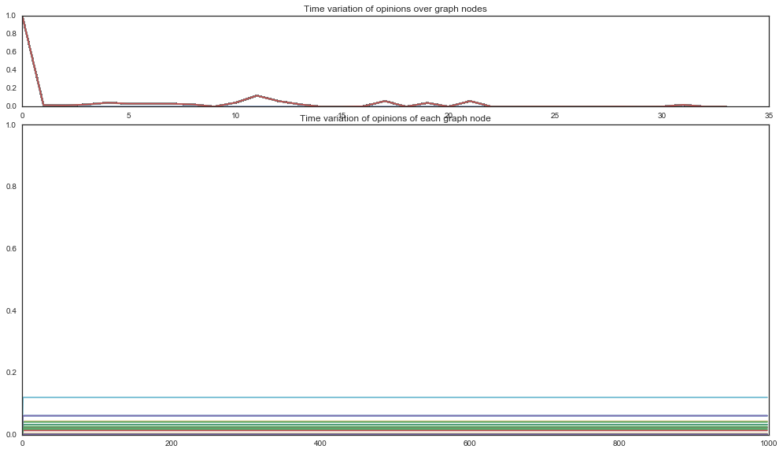

```python
sasd={}
for ii in G.nodes():
    if ii == source[0]:
        sasd[ii]=0
    else:
        sasd[ii]=susc[ii]

F,nodds,source,y_orig,final_d,no_zeros=influence_sim_dh_F_J_mu(n,p,iterations,G=G,scale=1000,
                    new_old=True,source = source,source_u=source_u,su=su,h=0.3,funcion=fjfun,
                    insrplot=False,no_change=False,
                    ssas_d=sasd,ax3ylim=(0.,1),ax4ylin=(0.,1))
```

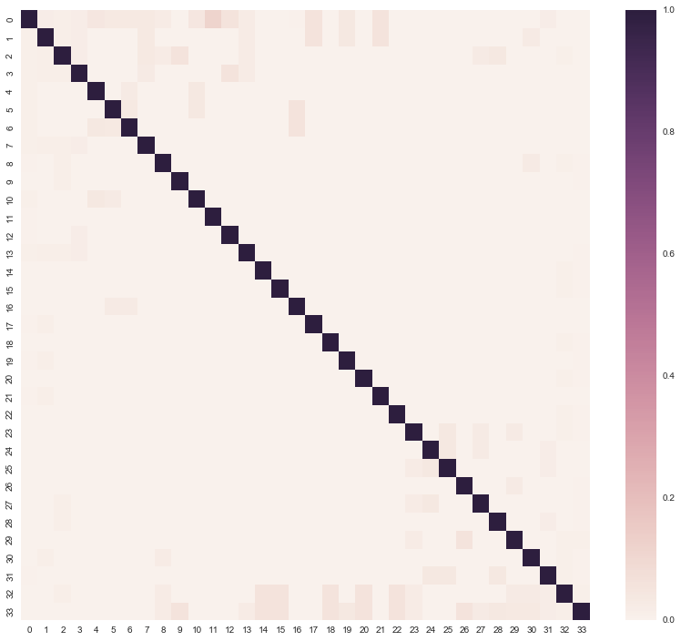

```python
%autoreload 2

from chAs import synthetic_multi_level_bip_dic
from steady_utils import steady_sols_calc_multi,steady_sols_calc_multi_one,steady_sols_calc_multi_one_cut
k=1
n=[n]
p=[p]
sas=susc #degrc #degggss
dic_of_Graphs_final={(0,0):G}
edgelist=G.edges()
try:
    os.stat('out')
except:
    os.mkdir('out')
os.chdir('out')

G,list_ofNod,steady_sols_dict,dic_of_nodes_multi,ssas_ds,no_iterations_dict,no_zero_time_dict,no_zero_val_dict,comparison_dict,steady_sols_dict_t=steady_sols_calc_multi_one_cut(k,G,dic_of_Graphs_final,n,p,sas,
    edgelist,iterations,fjfun,precision=.3,sa_u=0,source_u=[1.],su=1.,h=1.,form_float_val=6,form_float_val_stead=6)

data_s=crim.create_tex_tabul(G,list_ofNod,steady_sols_dict,dic_of_nodes_multi,outfile_name='stead_sols.tex')
crim.create_heat_maps_sea_s(G,list_ofNod,steady_sols_dict,dic_of_nodes_multi,ssas_ds,data_s,vm_s='stead_sols',outfile_name='3d.png',annot=False)
data_s=crim.create_tex_tabul(G,list_ofNod,no_iterations_dict,dic_of_nodes_multi,outfile_name='NoofIterations.tex')
data_s=crim.create_tex_tabul(G,list_ofNod,no_zero_time_dict,dic_of_nodes_multi,outfile_name='NoofZeroTime.tex')
data_s=crim.create_tex_tabul(G,list_ofNod,no_zero_val_dict,dic_of_nodes_multi,outfile_name='NoofZeroVal.tex')
crim.create_tex_tabul(G,list_ofNod,comparison_dict,dic_of_nodes_multi,outfile_name='Compare_NS_S.tex')

tem_dici,dici_tem= crim.create_tex_sum_steady(G,list_ofNod,steady_sols_dict_t,dic_of_nodes_multi,outfile_name='inOut.tex')
crim.create_tex_sum_steady_sub(G,k,list_ofNod,steady_sols_dict_t,dic_of_nodes_multi,outfile_name='inOut_sub.tex')
cent_dict=crim.create_tex_sum_central(G,tem_dici,dici_tem,dic_of_nodes_multi,outfile_name='scent_out.tex')
idici_tem,item_dici,odici_tem,otem_dici=crim.create_inf_nei_clos(G,list_ofNod,steady_sols_dict_t,dic_of_nodes_multi)
dinf_cinf_d=crim.create_dinf_tex(G,idici_tem,item_dici,odici_tem,otem_dici,list_ofNod,sas,ssas_ds)

def calc_centralization(dat_fr,col):
    mono=0
    dmax=max(dat_fr)
    for i in dat_fr:
        mono+=dmax-i
    return mono/len(dat_fr)

dinf_cinf_data=pd.DataFrame(dinf_cinf_d,columns=['Node','Influence-In-Degree','Influence-Out-Degree','In-CINF','OB_Closeness_CI','Degree','Closeness'])
```

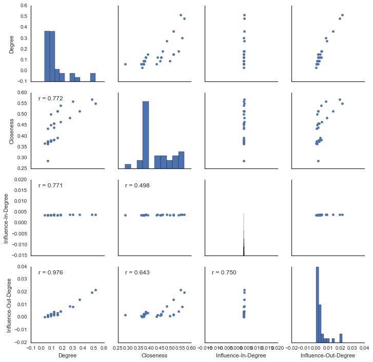

```python
columns=['Degree'  , 'Closeness','Influence-In-Degree', 'Influence-Out-Degree']
ndir=dinf_cinf_data[columns]

def corrfunc(x, y, **kws):
    r, _ = stats.pearsonr(x, y)
    ax = plt.gca()
    ax.annotate("r = {:.3f}".format(r),
                xy=(.1, .9), xycoords=ax.transAxes)

nel=len(columns)
g = sns.PairGrid(ndir)#, vars=columns)#,size=4)#,hue='Layer',size=4)#,palette="Set2",hue_kws={"marker": ["o", "s", "D"]})
g.map_upper(plt.scatter)#,color='grey')
g.map_diag(plt.hist)
g.map_lower(plt.scatter)#,color='grey')
g.map_lower(corrfunc)
```

```python
iod = ndir['Influence-Out-Degree'].tolist()
iid = ndir['Influence-In-Degree'].tolist()
# for i in range(len(G.nodes())):
#     print 'dc = %.4f, cc = %.4f, iod = %.4f, iid = %.4f' %(degggss[i],closs[i],iod[i],iid[i])
cdf=pd.DataFrame.from_items([('Nodes',degrc.keys()),('Degree Centrality',degrc.values()),
                             ('Closeness Centrality',closc.values()),
                             ('Influence-Out-Degree Centrality', iod),
                             ('Influence-In-Degree Centrality', iid)])
cdf#.head()
```

|  | Nodes | Degree Centrality | Closeness Centrality | Influence-Out-Degree Centrality | Influence-In-Degree Centrality |
| --- | --- | --- | --- | --- | --- |
| 0 | 0 | 0.484848 | 0.568966 | 0.019755 | 0.003897 |
| 1 | 1 | 0.272727 | 0.485294 | 0.008886 | 0.003880 |
| 2 | 2 | 0.303030 | 0.559322 | 0.008097 | 0.003817 |
| 3 | 3 | 0.181818 | 0.464789 | 0.004638 | 0.003891 |
| 4 | 4 | 0.090909 | 0.379310 | 0.002399 | 0.003768 |
| 5 | 5 | 0.121212 | 0.383721 | 0.004340 | 0.003831 |
| 6 | 6 | 0.121212 | 0.383721 | 0.004340 | 0.003831 |
| 7 | 7 | 0.121212 | 0.440000 | 0.001678 | 0.003812 |
| 8 | 8 | 0.151515 | 0.515625 | 0.002083 | 0.003766 |
| 9 | 9 | 0.060606 | 0.434211 | 0.000582 | 0.003656 |
| 10 | 10 | 0.090909 | 0.379310 | 0.002399 | 0.003768 |
| 11 | 11 | 0.030303 | 0.366667 | 0.000229 | 0.003649 |
| 12 | 12 | 0.060606 | 0.370787 | 0.000848 | 0.003707 |
| 13 | 13 | 0.151515 | 0.515625 | 0.001896 | 0.003786 |
| 14 | 14 | 0.060606 | 0.370787 | 0.000527 | 0.003695 |
| 15 | 15 | 0.060606 | 0.370787 | 0.000527 | 0.003695 |
| 16 | 16 | 0.060606 | 0.284483 | 0.001885 | 0.003767 |
| 17 | 17 | 0.060606 | 0.375000 | 0.000643 | 0.003697 |
| 18 | 18 | 0.060606 | 0.370787 | 0.000527 | 0.003695 |
| 19 | 19 | 0.090909 | 0.500000 | 0.000860 | 0.003686 |
| 20 | 20 | 0.060606 | 0.370787 | 0.000527 | 0.003695 |
| 21 | 21 | 0.060606 | 0.375000 | 0.000643 | 0.003697 |
| 22 | 22 | 0.060606 | 0.370787 | 0.000527 | 0.003695 |
| 23 | 23 | 0.151515 | 0.392857 | 0.003626 | 0.003767 |
| 24 | 24 | 0.090909 | 0.375000 | 0.002793 | 0.003735 |
| 25 | 25 | 0.090909 | 0.375000 | 0.002611 | 0.003735 |
| 26 | 26 | 0.060606 | 0.362637 | 0.001143 | 0.003724 |
| 27 | 27 | 0.121212 | 0.458333 | 0.002548 | 0.003693 |
| 28 | 28 | 0.090909 | 0.452055 | 0.001201 | 0.003692 |
| 29 | 29 | 0.121212 | 0.383721 | 0.003137 | 0.003804 |
| 30 | 30 | 0.121212 | 0.458333 | 0.001691 | 0.003739 |
| 31 | 31 | 0.181818 | 0.540984 | 0.004532 | 0.003756 |
| 32 | 32 | 0.363636 | 0.515625 | 0.013946 | 0.003877 |
| 33 | 33 | 0.515152 | 0.550000 | 0.021704 | 0.003865 |

## 2. Random Susceptibility Coefficients

```python
susc={}
for i in range(len(G.nodes())):
    susc[i]=random.random()

susc
```

```
{0: 0.9165096549112369,
 1: 0.8981924672715954,
 2: 0.46739503859007847,
 3: 0.774580667443564,
 4: 0.3865812217792711,
 5: 0.477898202273514,
 6: 0.25665658587123674,
 7: 0.522618842584279,
 8: 0.9804689259232238,
 9: 0.8028193580218063,
 10: 0.47933482619842205,
 11: 0.9969850901464484,
 12: 0.17043053320720247,
 13: 0.7288533093923616,
 14: 0.6451427086627132,
```

[output cut: 19 more lines]

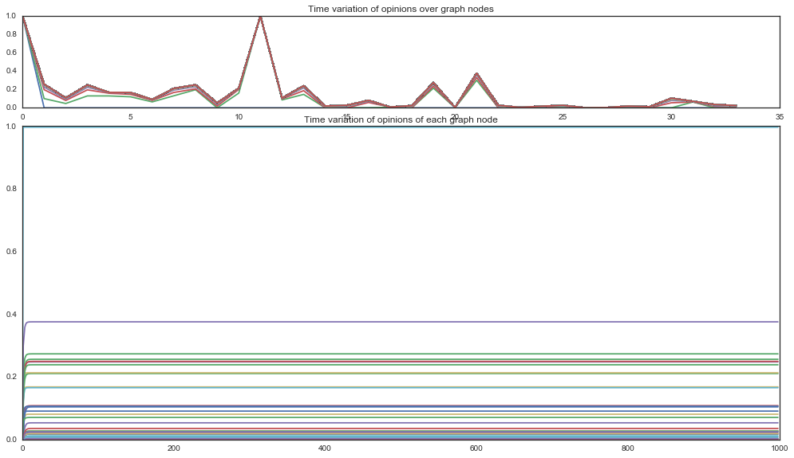

```python
sasd={}
for ii in G.nodes():
    if ii == source[0]:
        sasd[ii]=0
    else:
        sasd[ii]=susc[ii]

F,nodds,source,y_orig,final_d,no_zeros=influence_sim_dh_F_J_mu(n,p,iterations,G=G,scale=1000,
                    new_old=True,source = source,source_u=source_u,su=su,h=0.3,funcion=fjfun,
                    insrplot=False,no_change=False,
                    ssas_d=sasd,ax3ylim=(0.,1),ax4ylin=(0.,1))
```

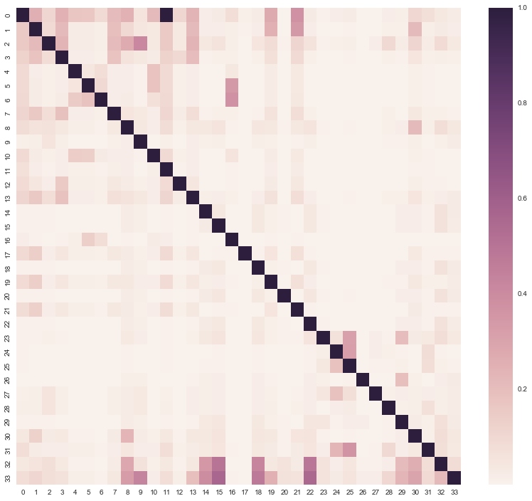

```python
%autoreload 2

from chAs import synthetic_multi_level_bip_dic
from steady_utils import steady_sols_calc_multi,steady_sols_calc_multi_one,steady_sols_calc_multi_one_cut
k=1
n=[n]
p=[p]
sas=susc #degrc #degggss
dic_of_Graphs_final={(0,0):G}
edgelist=G.edges()
try:
    os.stat('out')
except:
    os.mkdir('out')
os.chdir('out')

G,list_ofNod,steady_sols_dict,dic_of_nodes_multi,ssas_ds,no_iterations_dict,no_zero_time_dict,no_zero_val_dict,comparison_dict,steady_sols_dict_t=steady_sols_calc_multi_one_cut(k,G,dic_of_Graphs_final,n,p,sas,
    edgelist,iterations,fjfun,precision=.3,sa_u=0,source_u=[1.],su=1.,h=1.,form_float_val=6,form_float_val_stead=6)

data_s=crim.create_tex_tabul(G,list_ofNod,steady_sols_dict,dic_of_nodes_multi,outfile_name='stead_sols.tex')
crim.create_heat_maps_sea_s(G,list_ofNod,steady_sols_dict,dic_of_nodes_multi,ssas_ds,data_s,vm_s='stead_sols',outfile_name='3d.png',annot=False)
data_s=crim.create_tex_tabul(G,list_ofNod,no_iterations_dict,dic_of_nodes_multi,outfile_name='NoofIterations.tex')
data_s=crim.create_tex_tabul(G,list_ofNod,no_zero_time_dict,dic_of_nodes_multi,outfile_name='NoofZeroTime.tex')
data_s=crim.create_tex_tabul(G,list_ofNod,no_zero_val_dict,dic_of_nodes_multi,outfile_name='NoofZeroVal.tex')
crim.create_tex_tabul(G,list_ofNod,comparison_dict,dic_of_nodes_multi,outfile_name='Compare_NS_S.tex')

tem_dici,dici_tem= crim.create_tex_sum_steady(G,list_ofNod,steady_sols_dict_t,dic_of_nodes_multi,outfile_name='inOut.tex')
crim.create_tex_sum_steady_sub(G,k,list_ofNod,steady_sols_dict_t,dic_of_nodes_multi,outfile_name='inOut_sub.tex')
cent_dict=crim.create_tex_sum_central(G,tem_dici,dici_tem,dic_of_nodes_multi,outfile_name='scent_out.tex')
idici_tem,item_dici,odici_tem,otem_dici=crim.create_inf_nei_clos(G,list_ofNod,steady_sols_dict_t,dic_of_nodes_multi)
dinf_cinf_d=crim.create_dinf_tex(G,idici_tem,item_dici,odici_tem,otem_dici,list_ofNod,sas,ssas_ds)

def calc_centralization(dat_fr,col):
    mono=0
    dmax=max(dat_fr)
    for i in dat_fr:
        mono+=dmax-i
    return mono/len(dat_fr)

dinf_cinf_data=pd.DataFrame(dinf_cinf_d,columns=['Node','Influence-In-Degree', 'Influence-Out-Degree' , 'In-CINF'  , 'OB_Closeness_CI'   ,'Degree'  , 'Closeness'])
```

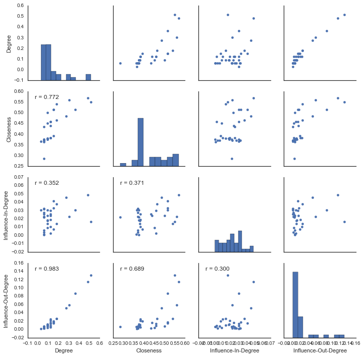

```python
columns=['Degree'  , 'Closeness','Influence-In-Degree', 'Influence-Out-Degree']
ndir=dinf_cinf_data[columns]

def corrfunc(x, y, **kws):
    r, _ = stats.pearsonr(x, y)
    ax = plt.gca()
    ax.annotate("r = {:.3f}".format(r),
                xy=(.1, .9), xycoords=ax.transAxes)

nel=len(columns)
g = sns.PairGrid(ndir)#, vars=columns)#,size=4)#,hue='Layer',size=4)#,palette="Set2",hue_kws={"marker": ["o", "s", "D"]})
g.map_upper(plt.scatter)#,color='grey')
g.map_diag(plt.hist)
g.map_lower(plt.scatter)#,color='grey')
g.map_lower(corrfunc)
```

```python
iod = ndir['Influence-Out-Degree'].tolist()
iid = ndir['Influence-In-Degree'].tolist()
# for i in range(len(G.nodes())):
#     print 'dc = %.4f, cc = %.4f, iod = %.4f, iid = %.4f' %(degggss[i],closs[i],iod[i],iid[i])
cdf=pd.DataFrame.from_items([('Nodes',degrc.keys()),('Degree Centrality',degrc.values()),
                             ('Closeness Centrality',closc.values()),
                             ('Influence-Out-Degree Centrality', iod),
                             ('Influence-In-Degree Centrality', iid)])
cdf#.head()
```

|  | Nodes | Degree Centrality | Closeness Centrality | Influence-Out-Degree Centrality | Influence-In-Degree Centrality |
| --- | --- | --- | --- | --- | --- |
| 0 | 0 | 0.484848 | 0.568966 | 0.114515 | 0.048859 |
| 1 | 1 | 0.272727 | 0.485294 | 0.051211 | 0.045641 |
| 2 | 2 | 0.303030 | 0.559322 | 0.058975 | 0.022294 |
| 3 | 3 | 0.181818 | 0.464789 | 0.026371 | 0.037557 |
| 4 | 4 | 0.090909 | 0.379310 | 0.010551 | 0.014019 |
| 5 | 5 | 0.121212 | 0.383721 | 0.021675 | 0.018883 |
| 6 | 6 | 0.121212 | 0.383721 | 0.024412 | 0.010192 |
| 7 | 7 | 0.121212 | 0.440000 | 0.016298 | 0.024050 |
| 8 | 8 | 0.151515 | 0.515625 | 0.014597 | 0.041447 |
| 9 | 9 | 0.060606 | 0.434211 | 0.002300 | 0.025641 |
| 10 | 10 | 0.090909 | 0.379310 | 0.011390 | 0.017483 |
| 11 | 11 | 0.030303 | 0.366667 | 0.002065 | 0.030212 |
| 12 | 12 | 0.060606 | 0.370787 | 0.007557 | 0.006126 |
| 13 | 13 | 0.151515 | 0.515625 | 0.017154 | 0.033072 |
| 14 | 14 | 0.060606 | 0.370787 | 0.002800 | 0.022485 |
| 15 | 15 | 0.060606 | 0.370787 | 0.002764 | 0.032267 |
| 16 | 16 | 0.060606 | 0.284483 | 0.006319 | 0.021768 |
| 17 | 17 | 0.060606 | 0.375000 | 0.006978 | 0.000469 |
| 18 | 18 | 0.060606 | 0.370787 | 0.002782 | 0.027475 |
| 19 | 19 | 0.090909 | 0.500000 | 0.007535 | 0.023556 |
| 20 | 20 | 0.060606 | 0.370787 | 0.002872 | 0.003670 |
| 21 | 21 | 0.060606 | 0.375000 | 0.006537 | 0.021859 |
| 22 | 22 | 0.060606 | 0.370787 | 0.002765 | 0.031895 |
| 23 | 23 | 0.151515 | 0.392857 | 0.019951 | 0.007609 |
| 24 | 24 | 0.090909 | 0.375000 | 0.012839 | 0.018262 |
| 25 | 25 | 0.090909 | 0.375000 | 0.009140 | 0.030490 |
| 26 | 26 | 0.060606 | 0.362637 | 0.006704 | 0.001086 |
| 27 | 27 | 0.121212 | 0.458333 | 0.009485 | 0.002360 |
| 28 | 28 | 0.090909 | 0.452055 | 0.004535 | 0.008971 |
| 29 | 29 | 0.121212 | 0.383721 | 0.004842 | 0.025476 |
| 30 | 30 | 0.121212 | 0.458333 | 0.014332 | 0.030118 |
| 31 | 31 | 0.181818 | 0.540984 | 0.026508 | 0.014228 |
| 32 | 32 | 0.363636 | 0.515625 | 0.087052 | 0.030600 |
| 33 | 33 | 0.515152 | 0.550000 | 0.130993 | 0.016683 |

## 3. Degree Centralities as Susceptibility Coefficients

```python
susc=degrc
susc
```

```
{0: 0.48484848484848486,
 1: 0.2727272727272727,
 2: 0.30303030303030304,
 3: 0.18181818181818182,
 4: 0.09090909090909091,
 5: 0.12121212121212122,
 6: 0.12121212121212122,
 7: 0.12121212121212122,
 8: 0.15151515151515152,
 9: 0.06060606060606061,
 10: 0.09090909090909091,
 11: 0.030303030303030304,
 12: 0.06060606060606061,
 13: 0.15151515151515152,
 14: 0.06060606060606061,
```

[output cut: 19 more lines]

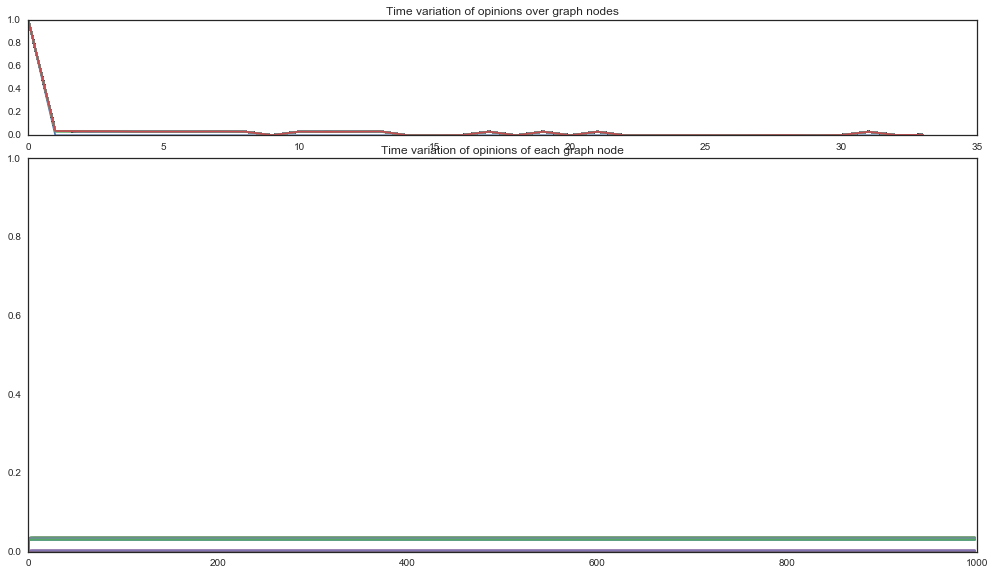

```python
sasd={}
for ii in G.nodes():
    if ii == source[0]:
        sasd[ii]=0
    else:
        sasd[ii]=susc[ii]

F,nodds,source,y_orig,final_d,no_zeros=influence_sim_dh_F_J_mu(n,p,iterations,G=G,scale=1000,
                    new_old=True,source = source,source_u=source_u,su=su,h=0.3,funcion=fjfun,
                    insrplot=False,no_change=False,
                    ssas_d=sasd,ax3ylim=(0.,1),ax4ylin=(0.,1))
```

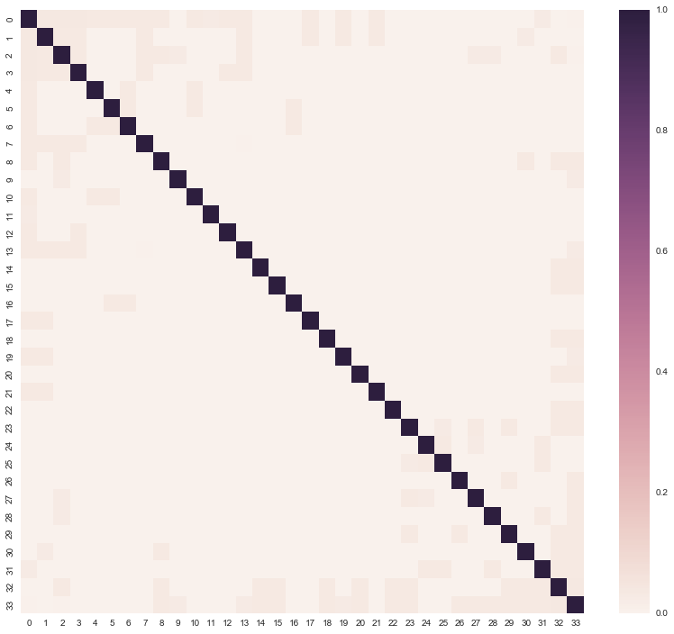

```python
%autoreload 2

from chAs import synthetic_multi_level_bip_dic
from steady_utils import steady_sols_calc_multi,steady_sols_calc_multi_one,steady_sols_calc_multi_one_cut
k=1
n=[n]
p=[p]
sas=susc #degrc #degggss
dic_of_Graphs_final={(0,0):G}
edgelist=G.edges()
try:
    os.stat('out')
except:
    os.mkdir('out')
os.chdir('out')

G,list_ofNod,steady_sols_dict,dic_of_nodes_multi,ssas_ds,no_iterations_dict,no_zero_time_dict,no_zero_val_dict,comparison_dict,steady_sols_dict_t=steady_sols_calc_multi_one_cut(k,G,dic_of_Graphs_final,n,p,sas,
    edgelist,iterations,fjfun,precision=.3,sa_u=0,source_u=[1.],su=1.,h=1.,form_float_val=6,form_float_val_stead=6)

data_s=crim.create_tex_tabul(G,list_ofNod,steady_sols_dict,dic_of_nodes_multi,outfile_name='stead_sols.tex')
crim.create_heat_maps_sea_s(G,list_ofNod,steady_sols_dict,dic_of_nodes_multi,ssas_ds,data_s,vm_s='stead_sols',outfile_name='3d.png',annot=False)
data_s=crim.create_tex_tabul(G,list_ofNod,no_iterations_dict,dic_of_nodes_multi,outfile_name='NoofIterations.tex')
data_s=crim.create_tex_tabul(G,list_ofNod,no_zero_time_dict,dic_of_nodes_multi,outfile_name='NoofZeroTime.tex')
data_s=crim.create_tex_tabul(G,list_ofNod,no_zero_val_dict,dic_of_nodes_multi,outfile_name='NoofZeroVal.tex')
crim.create_tex_tabul(G,list_ofNod,comparison_dict,dic_of_nodes_multi,outfile_name='Compare_NS_S.tex')

tem_dici,dici_tem= crim.create_tex_sum_steady(G,list_ofNod,steady_sols_dict_t,dic_of_nodes_multi,outfile_name='inOut.tex')
crim.create_tex_sum_steady_sub(G,k,list_ofNod,steady_sols_dict_t,dic_of_nodes_multi,outfile_name='inOut_sub.tex')
cent_dict=crim.create_tex_sum_central(G,tem_dici,dici_tem,dic_of_nodes_multi,outfile_name='scent_out.tex')
idici_tem,item_dici,odici_tem,otem_dici=crim.create_inf_nei_clos(G,list_ofNod,steady_sols_dict_t,dic_of_nodes_multi)
dinf_cinf_d=crim.create_dinf_tex(G,idici_tem,item_dici,odici_tem,otem_dici,list_ofNod,sas,ssas_ds)

def calc_centralization(dat_fr,col):
    mono=0
    dmax=max(dat_fr)
    for i in dat_fr:
        mono+=dmax-i
    return mono/len(dat_fr)

dinf_cinf_data=pd.DataFrame(dinf_cinf_d,columns=['Node','Influence-In-Degree', 'Influence-Out-Degree' , 'In-CINF'  , 'OB_Closeness_CI'   ,'Degree'  , 'Closeness'])
```

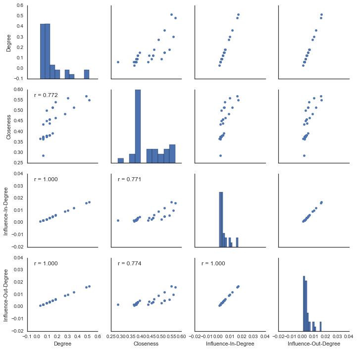

```python
columns=['Degree'  , 'Closeness','Influence-In-Degree', 'Influence-Out-Degree']
ndir=dinf_cinf_data[columns]

def corrfunc(x, y, **kws):
    r, _ = stats.pearsonr(x, y)
    ax = plt.gca()
    ax.annotate("r = {:.3f}".format(r),
                xy=(.1, .9), xycoords=ax.transAxes)

nel=len(columns)
g = sns.PairGrid(ndir)#, vars=columns)#,size=4)#,hue='Layer',size=4)#,palette="Set2",hue_kws={"marker": ["o", "s", "D"]})
g.map_upper(plt.scatter)#,color='grey')
g.map_diag(plt.hist)
g.map_lower(plt.scatter)#,color='grey')
g.map_lower(corrfunc)
```

```python
iod = ndir['Influence-Out-Degree'].tolist()
iid = ndir['Influence-In-Degree'].tolist()
# for i in range(len(G.nodes())):
#     print 'dc = %.4f, cc = %.4f, iod = %.4f, iid = %.4f' %(degggss[i],closs[i],iod[i],iid[i])
cdf=pd.DataFrame.from_items([('Nodes',degrc.keys()),('Degree Centrality',degrc.values()),
                             ('Closeness Centrality',closc.values()),
                             ('Influence-Out-Degree Centrality', iod),
                             ('Influence-In-Degree Centrality', iid)])
cdf#.head()
```

|  | Nodes | Degree Centrality | Closeness Centrality | Influence-Out-Degree Centrality | Influence-In-Degree Centrality |
| --- | --- | --- | --- | --- | --- |
| 0 | 0 | 0.484848 | 0.568966 | 0.015868 | 0.016053 |
| 1 | 1 | 0.272727 | 0.485294 | 0.009070 | 0.009098 |
| 2 | 2 | 0.303030 | 0.559322 | 0.009962 | 0.009995 |
| 3 | 3 | 0.181818 | 0.464789 | 0.006172 | 0.006161 |
| 4 | 4 | 0.090909 | 0.379310 | 0.002893 | 0.002880 |
| 5 | 5 | 0.121212 | 0.383721 | 0.003870 | 0.003861 |
| 6 | 6 | 0.121212 | 0.383721 | 0.003870 | 0.003861 |
| 7 | 7 | 0.121212 | 0.440000 | 0.004090 | 0.004065 |
| 8 | 8 | 0.151515 | 0.515625 | 0.004979 | 0.004946 |
| 9 | 9 | 0.060606 | 0.434211 | 0.001870 | 0.001848 |
| 10 | 10 | 0.090909 | 0.379310 | 0.002893 | 0.002880 |
| 11 | 11 | 0.030303 | 0.366667 | 0.000932 | 0.000918 |
| 12 | 12 | 0.060606 | 0.370787 | 0.001920 | 0.001902 |
| 13 | 13 | 0.151515 | 0.515625 | 0.005043 | 0.005011 |
| 14 | 14 | 0.060606 | 0.370787 | 0.001935 | 0.001911 |
| 15 | 15 | 0.060606 | 0.370787 | 0.001935 | 0.001911 |
| 16 | 16 | 0.060606 | 0.284483 | 0.001900 | 0.001896 |
| 17 | 17 | 0.060606 | 0.375000 | 0.001926 | 0.001906 |
| 18 | 18 | 0.060606 | 0.370787 | 0.001935 | 0.001911 |
| 19 | 19 | 0.090909 | 0.500000 | 0.002869 | 0.002838 |
| 20 | 20 | 0.060606 | 0.370787 | 0.001935 | 0.001911 |
| 21 | 21 | 0.060606 | 0.375000 | 0.001926 | 0.001906 |
| 22 | 22 | 0.060606 | 0.370787 | 0.001935 | 0.001911 |
| 23 | 23 | 0.151515 | 0.392857 | 0.004884 | 0.004869 |
| 24 | 24 | 0.090909 | 0.375000 | 0.002824 | 0.002820 |
| 25 | 25 | 0.090909 | 0.375000 | 0.002826 | 0.002822 |
| 26 | 26 | 0.060606 | 0.362637 | 0.001915 | 0.001898 |
| 27 | 27 | 0.121212 | 0.458333 | 0.003778 | 0.003760 |
| 28 | 28 | 0.090909 | 0.452055 | 0.002856 | 0.002833 |
| 29 | 29 | 0.121212 | 0.383721 | 0.003955 | 0.003935 |
| 30 | 30 | 0.121212 | 0.458333 | 0.003913 | 0.003886 |
| 31 | 31 | 0.181818 | 0.540984 | 0.005762 | 0.005744 |
| 32 | 32 | 0.363636 | 0.515625 | 0.011918 | 0.011998 |
| 33 | 33 | 0.515152 | 0.550000 | 0.016645 | 0.016861 |

## 4. Closeness Centralities as Susceptibility Coefficients

```python
susc=closc
susc
```

```
{0: 0.5689655172413793,
 1: 0.4852941176470588,
 2: 0.559322033898305,
 3: 0.4647887323943662,
 4: 0.3793103448275862,
 5: 0.38372093023255816,
 6: 0.38372093023255816,
 7: 0.44,
 8: 0.515625,
 9: 0.4342105263157895,
 10: 0.3793103448275862,
 11: 0.36666666666666664,
 12: 0.3707865168539326,
 13: 0.515625,
 14: 0.3707865168539326,
```

[output cut: 19 more lines]

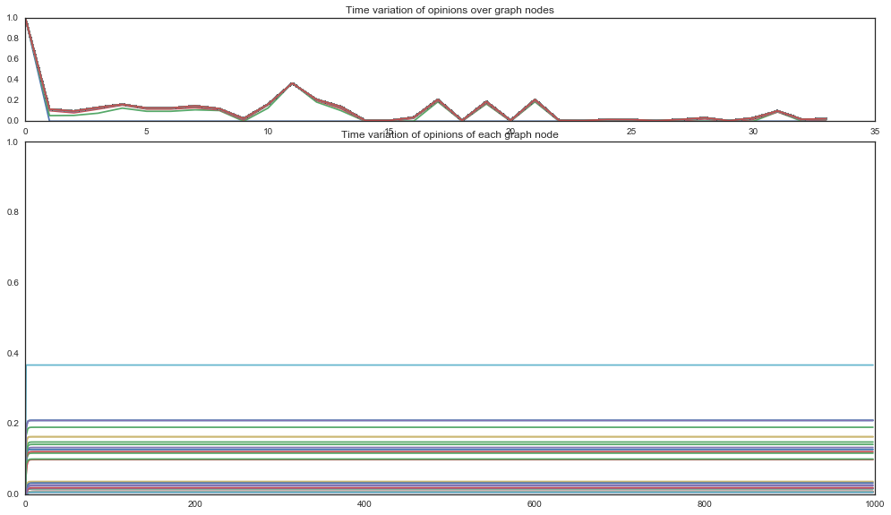

```python
sasd={}
for ii in G.nodes():
    if ii == source[0]:
        sasd[ii]=0
    else:
        sasd[ii]=susc[ii]

F,nodds,source,y_orig,final_d,no_zeros=influence_sim_dh_F_J_mu(n,p,iterations,G=G,scale=1000,
                    new_old=True,source = source,source_u=source_u,su=su,h=0.3,funcion=fjfun,
                    insrplot=False,no_change=False,
                    ssas_d=sasd,ax3ylim=(0.,1),ax4ylin=(0.,1))
```

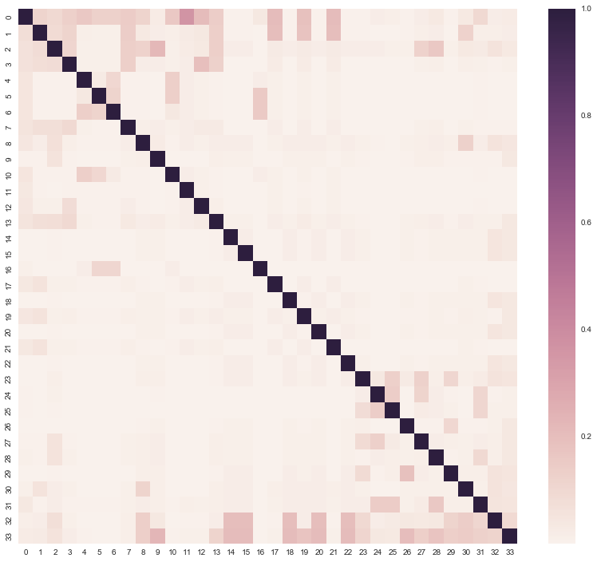

```python
%autoreload 2

from chAs import synthetic_multi_level_bip_dic
from steady_utils import steady_sols_calc_multi,steady_sols_calc_multi_one,steady_sols_calc_multi_one_cut
k=1
n=[n]
p=[p]
sas=susc #degrc #degggss
dic_of_Graphs_final={(0,0):G}
edgelist=G.edges()
try:
    os.stat('out')
except:
    os.mkdir('out')
os.chdir('out')

G,list_ofNod,steady_sols_dict,dic_of_nodes_multi,ssas_ds,no_iterations_dict,no_zero_time_dict,no_zero_val_dict,comparison_dict,steady_sols_dict_t=steady_sols_calc_multi_one_cut(k,G,dic_of_Graphs_final,n,p,sas,
    edgelist,iterations,fjfun,precision=.3,sa_u=0,source_u=[1.],su=1.,h=1.,form_float_val=6,form_float_val_stead=6)

data_s=crim.create_tex_tabul(G,list_ofNod,steady_sols_dict,dic_of_nodes_multi,outfile_name='stead_sols.tex')
crim.create_heat_maps_sea_s(G,list_ofNod,steady_sols_dict,dic_of_nodes_multi,ssas_ds,data_s,vm_s='stead_sols',outfile_name='3d.png',annot=False)
data_s=crim.create_tex_tabul(G,list_ofNod,no_iterations_dict,dic_of_nodes_multi,outfile_name='NoofIterations.tex')
data_s=crim.create_tex_tabul(G,list_ofNod,no_zero_time_dict,dic_of_nodes_multi,outfile_name='NoofZeroTime.tex')
data_s=crim.create_tex_tabul(G,list_ofNod,no_zero_val_dict,dic_of_nodes_multi,outfile_name='NoofZeroVal.tex')
crim.create_tex_tabul(G,list_ofNod,comparison_dict,dic_of_nodes_multi,outfile_name='Compare_NS_S.tex')

tem_dici,dici_tem= crim.create_tex_sum_steady(G,list_ofNod,steady_sols_dict_t,dic_of_nodes_multi,outfile_name='inOut.tex')
crim.create_tex_sum_steady_sub(G,k,list_ofNod,steady_sols_dict_t,dic_of_nodes_multi,outfile_name='inOut_sub.tex')
cent_dict=crim.create_tex_sum_central(G,tem_dici,dici_tem,dic_of_nodes_multi,outfile_name='scent_out.tex')
idici_tem,item_dici,odici_tem,otem_dici=crim.create_inf_nei_clos(G,list_ofNod,steady_sols_dict_t,dic_of_nodes_multi)
dinf_cinf_d=crim.create_dinf_tex(G,idici_tem,item_dici,odici_tem,otem_dici,list_ofNod,sas,ssas_ds)

def calc_centralization(dat_fr,col):
    mono=0
    dmax=max(dat_fr)
    for i in dat_fr:
        mono+=dmax-i
    return mono/len(dat_fr)

dinf_cinf_data=pd.DataFrame(dinf_cinf_d,columns=['Node','Influence-In-Degree', 'Influence-Out-Degree' , 'In-CINF'  , 'OB_Closeness_CI'   ,'Degree'  , 'Closeness'])
```

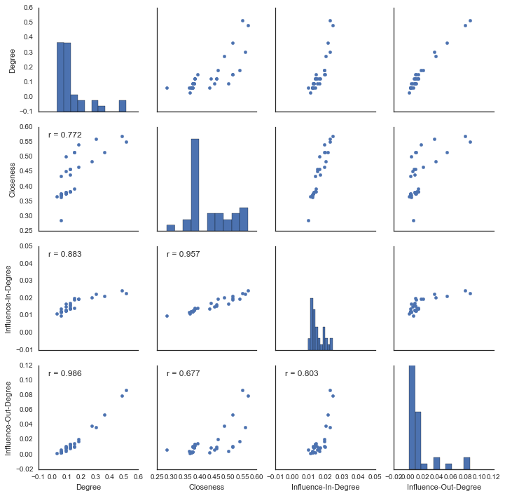

```python
columns=['Degree'  , 'Closeness','Influence-In-Degree', 'Influence-Out-Degree']
ndir=dinf_cinf_data[columns]

def corrfunc(x, y, **kws):
    r, _ = stats.pearsonr(x, y)
    ax = plt.gca()
    ax.annotate("r = {:.3f}".format(r),
                xy=(.1, .9), xycoords=ax.transAxes)

nel=len(columns)
g = sns.PairGrid(ndir)#, vars=columns)#,size=4)#,hue='Layer',size=4)#,palette="Set2",hue_kws={"marker": ["o", "s", "D"]})
g.map_upper(plt.scatter)#,color='grey')
g.map_diag(plt.hist)
g.map_lower(plt.scatter)#,color='grey')
g.map_lower(corrfunc)
```

```python
iod = ndir['Influence-Out-Degree'].tolist()
iid = ndir['Influence-In-Degree'].tolist()
# for i in range(len(G.nodes())):
#     print 'dc = %.4f, cc = %.4f, iod = %.4f, iid = %.4f' %(degggss[i],closs[i],iod[i],iid[i])
cdf=pd.DataFrame.from_items([('Nodes',degrc.keys()),('Degree Centrality',degrc.values()),
                             ('Closeness Centrality',closc.values()),
                             ('Influence-Out-Degree Centrality', iod),
                             ('Influence-In-Degree Centrality', iid)])
cdf#.head()
```

|  | Nodes | Degree Centrality | Closeness Centrality | Influence-Out-Degree Centrality | Influence-In-Degree Centrality |
| --- | --- | --- | --- | --- | --- |
| 0 | 0 | 0.484848 | 0.568966 | 0.079518 | 0.024355 |
| 1 | 1 | 0.272727 | 0.485294 | 0.038366 | 0.020326 |
| 2 | 2 | 0.303030 | 0.559322 | 0.037012 | 0.022560 |
| 3 | 3 | 0.181818 | 0.464789 | 0.020815 | 0.019382 |
| 4 | 4 | 0.090909 | 0.379310 | 0.008800 | 0.013247 |
| 5 | 5 | 0.121212 | 0.383721 | 0.014130 | 0.013976 |
| 6 | 6 | 0.121212 | 0.383721 | 0.014130 | 0.013976 |
| 7 | 7 | 0.121212 | 0.440000 | 0.008889 | 0.017058 |
| 8 | 8 | 0.151515 | 0.515625 | 0.010534 | 0.019255 |
| 9 | 9 | 0.060606 | 0.434211 | 0.002958 | 0.013751 |
| 10 | 10 | 0.090909 | 0.379310 | 0.008800 | 0.013247 |
| 11 | 11 | 0.030303 | 0.366667 | 0.001172 | 0.011111 |
| 12 | 12 | 0.060606 | 0.370787 | 0.003889 | 0.012340 |
| 13 | 13 | 0.151515 | 0.515625 | 0.010189 | 0.019801 |
| 14 | 14 | 0.060606 | 0.370787 | 0.002701 | 0.012411 |
| 15 | 15 | 0.060606 | 0.370787 | 0.002701 | 0.012411 |
| 16 | 16 | 0.060606 | 0.284483 | 0.006603 | 0.009653 |
| 17 | 17 | 0.060606 | 0.375000 | 0.003156 | 0.012475 |
| 18 | 18 | 0.060606 | 0.370787 | 0.002701 | 0.012411 |
| 19 | 19 | 0.090909 | 0.500000 | 0.004319 | 0.016646 |
| 20 | 20 | 0.060606 | 0.370787 | 0.002701 | 0.012411 |
| 21 | 21 | 0.060606 | 0.375000 | 0.003156 | 0.012475 |
| 22 | 22 | 0.060606 | 0.370787 | 0.002701 | 0.012411 |
| 23 | 23 | 0.151515 | 0.392857 | 0.014344 | 0.014261 |
| 24 | 24 | 0.090909 | 0.375000 | 0.011124 | 0.012723 |
| 25 | 25 | 0.090909 | 0.375000 | 0.010048 | 0.012726 |
| 26 | 26 | 0.060606 | 0.362637 | 0.004284 | 0.012018 |
| 27 | 27 | 0.121212 | 0.458333 | 0.009733 | 0.015341 |
| 28 | 28 | 0.090909 | 0.452055 | 0.006103 | 0.015131 |
| 29 | 29 | 0.121212 | 0.383721 | 0.011632 | 0.014132 |
| 30 | 30 | 0.121212 | 0.458333 | 0.008383 | 0.016396 |
| 31 | 31 | 0.181818 | 0.540984 | 0.018011 | 0.019558 |
| 32 | 32 | 0.363636 | 0.515625 | 0.053950 | 0.021375 |
| 33 | 33 | 0.515152 | 0.550000 | 0.086757 | 0.022961 |